# Meta-Análise

## O que é Meta-análise?

- Revisão sistemática para análise estatística de dados extraídos de estudos
- Permite conclusões mais amplas e robustas

## Revisão x Meta-análise

**Revisão narrativa**: descritiva, qualitativa, textual  
**Revisão sistemática**: revisão com protocolos claros e reprodutíveis  
**Meta-análise**: revisão sistemática + análise estatística

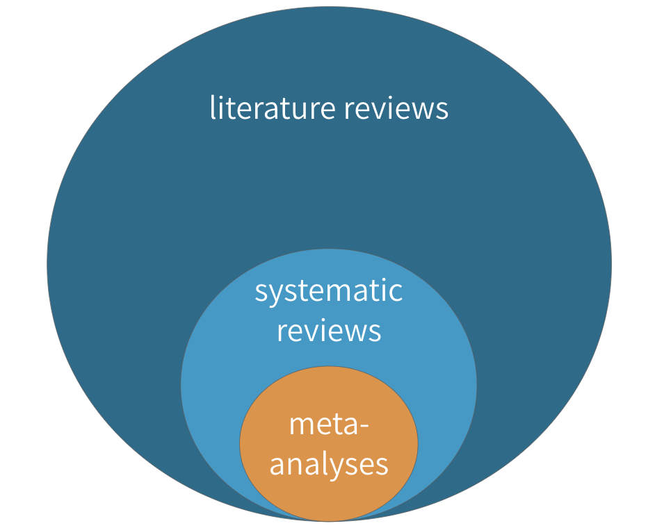

## Etapas principais

1. Formulação da pergunta
2. Busca sistemática na literatura (critérios de inclusão)
3. Extração de dados
4. Avaliação da qualidade dos estudos (viés, variabilidade, funnel plot)
5. Análise estatística (metanálise, forest plot)

## Exemplo

- Artigo: Climatic seasonality of the Cerrado and aquatic insect communities: a systematic review with meta-analysis ([Ferreira et al., 2025](https://link.springer.com/article/10.1007/s10661-025-13783-3))
- Pergunta: as comunidades de insetos aquáticos variam com as estações seca e chuvosa no Cerrado?
- Variáveis: abundância, riqueza de espécies
- Tipo de efeito: diferença média padronizada

## Símbolos e operadores booleanos de busca

- *, $
- AND, NOT, OR

(“Stream*” **OR** “headwater*”) AND (“Aquatic insect*” **OR** “Ephemeroptera*” **OR** “Plecoptera*” **OR** “Trichoptera*” **OR** “EPT*” **OR** “Odonata*” **OR** “Heteroptera*” **OR** “Chironomid*”) AND (“Cerrado*” **OR** “Brazilian savanna*“) NOT ”Pantan*”

## Estrutura do Banco de Dados

- Cada linha = um estudo incluído/entrada de um estudo
- Colunas: autores, ano, local, tamanho da amostra, fatores ambientais… variáveis resposta, medidas de tamanho de efeito (OR/RR/MD) das variáveis, desvio padrão
- Necessário padronizar as medidas antes da análise

## Forest plot

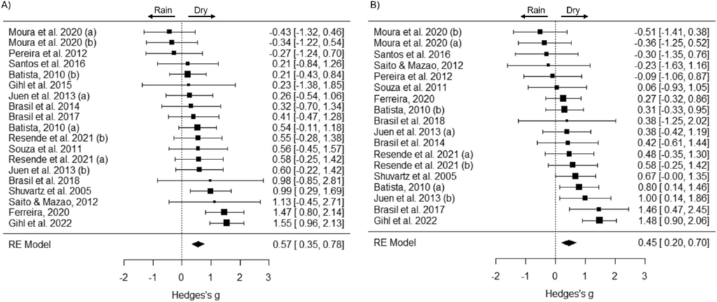

Forest plot of effect sizes (Hedges’ g) of climatic seasonality on (A) abundance and (B) richness of aquatic insects, along with 95% confidence intervals

## Exemplo de Banco de Dados

```r
library(metafor) # Pacote metafor do R
head(dat.bcg)    # Eficácia de vacina BCG contra tuberculose
```

```
##   trial               author year tpos  tneg cpos  cneg ablat     alloc
## 1     1              Aronson 1948    4   119   11   128    44    random
## 2     2     Ferguson & Simes 1949    6   300   29   274    55    random
## 3     3      Rosenthal et al 1960    3   228   11   209    42    random
## 4     4    Hart & Sutherland 1977   62 13536  248 12619    52    random
## 5     5 Frimodt-Moller et al 1973   33  5036   47  5761    13 alternate
## 6     6      Stein & Aronson 1953  180  1361  372  1079    44 alternate
```

**tpos/tneg**: no. TB positive/negative cases in the treated group; **cpos/cnes**: no. TB positive/negative cases in the control group; **ablat**: absolute latitude; **alloc**: method of treatment allocation (random, alternate, or systematic assignment)

## Forest plot

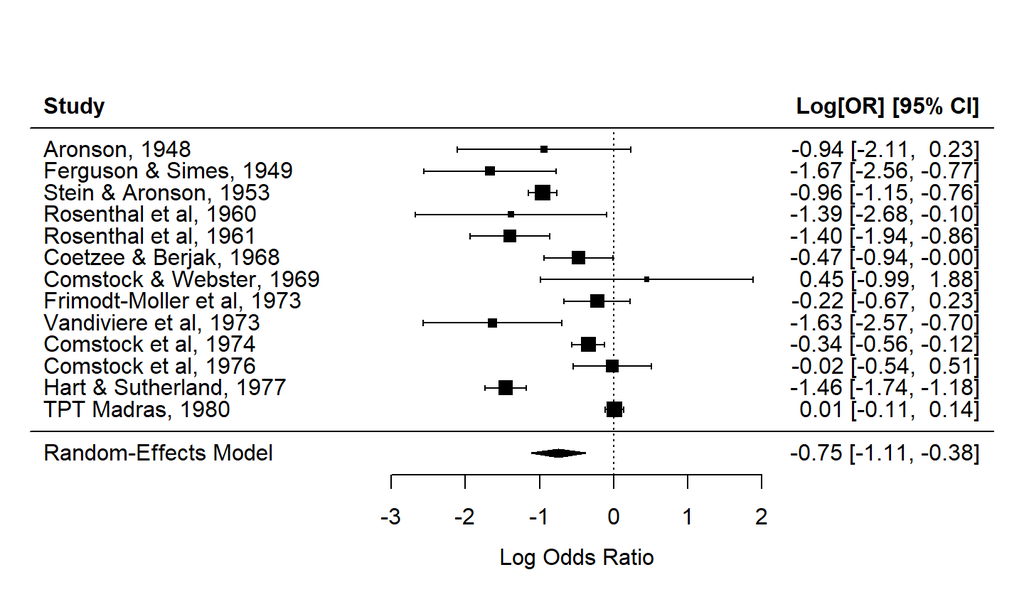